```r
#Below t.test() results gives us a positive number for 't', meaning, the fertiltiy or children/woman is higher in african countries compared to non african nations.

t.test(africanCountriesData$fertility,nonAfricanCountriesData$fertility)
```

```
##
##  Welch Two Sample t-test
##
## data:  africanCountriesData$fertility and nonAfricanCountriesData$fertility
## t = 10.414, df = 69.529, p-value = 7.79e-16
## alternative hypothesis: true difference in means is not equal to 0
## 95 percent confidence interval:
##  1.625143 2.395165
## sample estimates:
## mean of x mean of y
##  4.236170  2.226016
```

```r
#Below t.test() results gives us a positive number for 't', meaning, the life expectancy in woman is higher in non african countries when compared to african nations.

t.test(nonAfricanCountriesData$lifeExpF,africanCountriesData$lifeExpF)
```

```
##
##  Welch Two Sample t-test
##
## data:  nonAfricanCountriesData$lifeExpF and africanCountriesData$lifeExpF
## t = 13.235, df = 70.134, p-value < 2.2e-16
## alternative hypothesis: true difference in means is not equal to 0
## 95 percent confidence interval:
##  14.49443 19.63796
## sample estimates:
## mean of x mean of y
##  76.83846  59.77226
```

```r
#Below t.test() results gives us a positive number for 't', meaning, the infant mortality rate per 1000 live births is higher in african countries when compared to non african nations.

t.test(africanCountriesData$infantMortality,nonAfricanCountriesData$infantMortality)
```

```
##
##  Welch Two Sample t-test
##
## data:  africanCountriesData$infantMortality and nonAfricanCountriesData$infantMortality
## t = 11.616, df = 65.906, p-value < 2.2e-16
## alternative hypothesis: true difference in means is not equal to 0
## 95 percent confidence interval:
##  39.19908 55.47145
## sample estimates:
## mean of x mean of y
##  65.32077  17.98550
```

Hypothesis (Preliminary Conclusions observing the dataset) : All the variables look to be dependent on each other, the higher the urban percentage (pcturban), the better GDP/ quality of living (ppgdp), the lower the fertility ratio (fertiltiy - number of children/woman) - which means better education on family planning/population control, higher the life expectancy for female - probability of deaths during pregnancy is lower as the fertility ratio is low and lower the infant mortality ratio (death of infants under age 1 per 1000 live births).

```r
#2. Data wrangling: Please perform some basic transformations. They will need to make sense but could include column renaming, creating a subset of the data, replacing values, or creating new columns with derived data (for example - if it makes sense you could sum two columns together)

#We have already created four subset data frames -
#africanCountriesData
#nonAfricanCountriesData
#oecdCountriesData
#otherCountriesData

#Renaming the column names in both the data frames with meaningful names

colnames(africanCountriesData) <- c("COUNTRY_NAME","COUNTRY_REGION","COUNTRY_GROUP","NO_OF_CHILDREN_PER_WOMAN","GDP","FEMALE_LIFE_EXPECTANCY","URBAN_POPULATION_PERCENTAGE","INFANT_DEATH_RATE_PER_THOUSAND")
summary.data.frame(africanCountriesData)
```

```
##        COUNTRY_NAME       COUNTRY_REGION COUNTRY_GROUP
##  Algeria     : 1    Africa       :53     africa:53
##  Angola      : 1    Asia         : 0     oecd  : 0
##  Benin       : 1    Caribbean    : 0     other : 0
##  Botswana    : 1    Europe       : 0
##  Burkina Faso: 1    Latin Amer   : 0
##  Burundi     : 1    North America: 0
##  (Other)     :47    (Other)      : 0
##  NO_OF_CHILDREN_PER_WOMAN      GDP          FEMALE_LIFE_EXPECTANCY
##  Min.   :1.590            Min.   :  114.8   Min.   :48.11
##  1st Qu.:3.174            1st Qu.:  509.0   1st Qu.:53.14
##  Median :4.423            Median :  980.7   Median :58.59
##  Mean   :4.236            Mean   : 2508.8   Mean   :59.77
##  3rd Qu.:5.078            3rd Qu.: 2865.0   3rd Qu.:63.82
##  Max.   :6.925            Max.   :16852.4   Max.   :78.00
##
##  URBAN_POPULATION_PERCENTAGE INFANT_DEATH_RATE_PER_THOUSAND
##  Min.   :11.00               Min.   : 12.11
##  1st Qu.:28.00               1st Qu.: 46.94
##  Median :40.00               Median : 67.02
##  Mean   :42.62               Mean   : 65.32
##  3rd Qu.:59.00               3rd Qu.: 85.88
##  Max.   :86.00               Max.   :123.94
##                              NA's   :1
```

```r
colnames(nonAfricanCountriesData) <- c("COUNTRY_NAME","COUNTRY_REGION","COUNTRY_GROUP","NO_OF_CHILDREN_PER_WOMAN","GDP","FEMALE_LIFE_EXPECTANCY","URBAN_POPULATION_PERCENTAGE","INFANT_DEATH_RATE_PER_THOUSAND")
summary.data.frame(nonAfricanCountriesData)
```

```
##       COUNTRY_NAME       COUNTRY_REGION COUNTRY_GROUP
##  Afghanistan:  1   Asia         :50     africa:  0
##  Albania    :  1   Europe       :39     oecd  : 31
##  Anguilla   :  1   Latin Amer   :20     other :115
##  Argentina  :  1   Caribbean    :17
##  Armenia    :  1   Oceania      :17
##  Aruba      :  1   North America: 2
##  (Other)    :140   (Other)      : 1
##  NO_OF_CHILDREN_PER_WOMAN      GDP         FEMALE_LIFE_EXPECTANCY
##  Min.   :1.134            Min.   :   499   Min.   :49.49
##  1st Qu.:1.578            1st Qu.:  3005   1st Qu.:73.70
##  Median :2.011            Median :  7568   Median :77.50
##  Mean   :2.226            Mean   : 16825   Mean   :76.84
##  3rd Qu.:2.498            3rd Qu.: 24279   3rd Qu.:81.26
##  Max.   :5.968            Max.   :105095   Max.   :87.12
##
##  URBAN_POPULATION_PERCENTAGE INFANT_DEATH_RATE_PER_THOUSAND
##  Min.   : 13.00              Min.   :  1.916
##  1st Qu.: 49.25              1st Qu.:  5.405
##  Median : 67.00              Median : 13.063
##  Mean   : 63.49              Mean   : 17.985
##  3rd Qu.: 81.75              3rd Qu.: 23.515
##  Max.   :100.00              Max.   :124.535
##                              NA's   :5
```

```r
colnames(oecdCountriesData) <- c("COUNTRY_NAME","COUNTRY_REGION","COUNTRY_GROUP","NO_OF_CHILDREN_PER_WOMAN","GDP","FEMALE_LIFE_EXPECTANCY","URBAN_POPULATION_PERCENTAGE","INFANT_DEATH_RATE_PER_THOUSAND")
summary.data.frame(oecdCountriesData)
```

```
##          COUNTRY_NAME       COUNTRY_REGION COUNTRY_GROUP
##  Australia     : 1    Europe       :22     africa: 0
##  Austria       : 1    Asia         : 3     oecd  :31
##  Belgium       : 1    Latin Amer   : 2     other : 0
##  Canada        : 1    North America: 2
##  Chile         : 1    Oceania      : 2
##  Czech Republic: 1    Africa       : 0
##  (Other)       :25    (Other)      : 0
##  NO_OF_CHILDREN_PER_WOMAN      GDP         FEMALE_LIFE_EXPECTANCY
##  Min.   :1.312            Min.   :  9101   Min.   :76.61
##  1st Qu.:1.476            1st Qu.: 20138   1st Qu.:81.34
##  Median :1.794            Median : 39546   Median :82.79
##  Mean   :1.765            Mean   : 37761   Mean   :82.45
##  3rd Qu.:1.948            3rd Qu.: 46453   3rd Qu.:83.52
##  Max.   :2.909            Max.   :105095   Max.   :87.12
##
##  URBAN_POPULATION_PERCENTAGE INFANT_DEATH_RATE_PER_THOUSAND
##  Min.   :49.00               Min.   : 2.289
##  1st Qu.:68.00               1st Qu.: 3.346
##  Median :78.00               Median : 3.914
##  Mean   :75.81               Mean   : 4.890
##  3rd Qu.:85.00               3rd Qu.: 4.841
##  Max.   :97.00               Max.   :19.901
##
```

```r
colnames(otherCountriesData) <- c("COUNTRY_NAME","COUNTRY_REGION","COUNTRY_GROUP","NO_OF_CHILDREN_PER_WOMAN","GDP","FEMALE_LIFE_EXPECTANCY","URBAN_POPULATION_PERCENTAGE","INFANT_DEATH_RATE_PER_THOUSAND")
summary.data.frame(otherCountriesData)
```

```
##       COUNTRY_NAME       COUNTRY_REGION COUNTRY_GROUP
##  Afghanistan:  1   Asia         :47     africa:  0
##  Albania    :  1   Latin Amer   :18     oecd  :  0
##  Anguilla   :  1   Caribbean    :17     other :115
##  Argentina  :  1   Europe       :17
##  Armenia    :  1   Oceania      :15
##  Aruba      :  1   NorthAtlantic: 1
##  (Other)    :109   (Other)      : 0
##  NO_OF_CHILDREN_PER_WOMAN      GDP        FEMALE_LIFE_EXPECTANCY
##  Min.   :1.134            Min.   :  499   Min.   :49.49
##  1st Qu.:1.650            1st Qu.: 2527   1st Qu.:72.47
##  Median :2.171            Median : 5195   Median :76.37
##  Mean   :2.350            Mean   :11181   Mean   :75.33
##  3rd Qu.:2.611            3rd Qu.:12857   3rd Qu.:78.34
##  Max.   :5.968            Max.   :92625   Max.   :86.35
##
##  URBAN_POPULATION_PERCENTAGE INFANT_DEATH_RATE_PER_THOUSAND
##  Min.   : 13.00              Min.   :  1.916
##  1st Qu.: 44.50              1st Qu.: 10.558
##  Median : 60.00              Median : 18.268
##  Mean   : 60.17              Mean   : 21.676
##  3rd Qu.: 76.00              3rd Qu.: 26.098
##  Max.   :100.00              Max.   :124.535
##                              NA's   :5
```

```r
colnames(UNStatistics) <- c("COUNTRY_NAME","COUNTRY_REGION","COUNTRY_GROUP","NO_OF_CHILDREN_PER_WOMAN","GDP","FEMALE_LIFE_EXPECTANCY","URBAN_POPULATION_PERCENTAGE","INFANT_DEATH_RATE_PER_THOUSAND")
summary.data.frame(UNStatistics)
```

```
##          COUNTRY_NAME    COUNTRY_REGION COUNTRY_GROUP
##  Afghanistan   :  1   Africa    :53     africa: 53
##  Albania       :  1   Asia      :50     oecd  : 31
##  Algeria       :  1   Europe    :39     other :115
##  American Samoa:  1   Latin Amer:20     NA's  : 14
##  Angola        :  1   Caribbean :17
##  Anguilla      :  1   (Other)   :20
##  (Other)       :207   NA's      :14
##  NO_OF_CHILDREN_PER_WOMAN      GDP           FEMALE_LIFE_EXPECTANCY
##  Min.   :1.134            Min.   :   114.8   Min.   :48.11
##  1st Qu.:1.754            1st Qu.:  1283.0   1st Qu.:65.66
##  Median :2.262            Median :  4684.5   Median :75.89
##  Mean   :2.761            Mean   : 13012.0   Mean   :72.29
##  3rd Qu.:3.545            3rd Qu.: 15520.5   3rd Qu.:79.58
##  Max.   :6.925            Max.   :105095.4   Max.   :87.12
##  NA's   :14               NA's   :14         NA's   :14
##  URBAN_POPULATION_PERCENTAGE INFANT_DEATH_RATE_PER_THOUSAND
##  Min.   : 11.00              Min.   :  1.916
##  1st Qu.: 39.00              1st Qu.:  7.019
##  Median : 59.00              Median : 19.007
##  Mean   : 57.93              Mean   : 29.440
##  3rd Qu.: 75.00              3rd Qu.: 44.477
##  Max.   :100.00              Max.   :124.535
##  NA's   :14                  NA's   :6
```

```r
#Creating new columns with derived data

#Adding a new column called "SERIAL_NUMBER"

africanCountriesData$SERIAL_NUMBER <- c(1:nrow(africanCountriesData))

#Get Rural population percentage by subtracting 100 from urban population

africanRuralPercentage <- as.integer(100 - africanCountriesData$URBAN_POPULATION_PERCENTAGE)

#Add RURAL_POPULATION_PERCENTAGE to the data frame

africanCountriesData$RURAL_POPULATION_PERCENTAGE <- africanRuralPercentage

#Find the GDP contribution by URBAN_POPULATION
africanUrbanGDPContribution <- africanCountriesData$GDP * (africanCountriesData$URBAN_POPULATION_PERCENTAGE / 100)
africanCountriesData$GDP_URBAN_CONTRIBUTION <- africanUrbanGDPContribution


#Find the GDP contribution by RURAL_POPULATION
africanRuralGDPContribution <- africanCountriesData$GDP * (africanCountriesData$RURAL_POPULATION_PERCENTAGE / 100)
africanCountriesData$GDP_RURAL_CONTRIBUTION <- africanRuralGDPContribution

#Arranging the columns to a meaningful order

africanCountriesData <- africanCountriesData[,c("SERIAL_NUMBER","COUNTRY_NAME","COUNTRY_REGION","COUNTRY_GROUP","NO_OF_CHILDREN_PER_WOMAN","GDP","FEMALE_LIFE_EXPECTANCY","URBAN_POPULATION_PERCENTAGE","RURAL_POPULATION_PERCENTAGE","GDP_URBAN_CONTRIBUTION","GDP_RURAL_CONTRIBUTION","INFANT_DEATH_RATE_PER_THOUSAND")]
names(africanCountriesData)
```

```
##  [1] "SERIAL_NUMBER"                  "COUNTRY_NAME"
##  [3] "COUNTRY_REGION"                 "COUNTRY_GROUP"
##  [5] "NO_OF_CHILDREN_PER_WOMAN"       "GDP"
##  [7] "FEMALE_LIFE_EXPECTANCY"         "URBAN_POPULATION_PERCENTAGE"
##  [9] "RURAL_POPULATION_PERCENTAGE"    "GDP_URBAN_CONTRIBUTION"
## [11] "GDP_RURAL_CONTRIBUTION"         "INFANT_DEATH_RATE_PER_THOUSAND"
```

```r
summary.data.frame(africanCountriesData)
```

```
##  SERIAL_NUMBER       COUNTRY_NAME       COUNTRY_REGION COUNTRY_GROUP
##  Min.   : 1    Algeria     : 1    Africa       :53     africa:53
##  1st Qu.:14    Angola      : 1    Asia         : 0     oecd  : 0
##  Median :27    Benin       : 1    Caribbean    : 0     other : 0
##  Mean   :27    Botswana    : 1    Europe       : 0
##  3rd Qu.:40    Burkina Faso: 1    Latin Amer   : 0
##  Max.   :53    Burundi     : 1    North America: 0
##                (Other)     :47    (Other)      : 0
##  NO_OF_CHILDREN_PER_WOMAN      GDP          FEMALE_LIFE_EXPECTANCY
##  Min.   :1.590            Min.   :  114.8   Min.   :48.11
##  1st Qu.:3.174            1st Qu.:  509.0   1st Qu.:53.14
##  Median :4.423            Median :  980.7   Median :58.59
##  Mean   :4.236            Mean   : 2508.8   Mean   :59.77
##  3rd Qu.:5.078            3rd Qu.: 2865.0   3rd Qu.:63.82
##  Max.   :6.925            Max.   :16852.4   Max.   :78.00
##
##  URBAN_POPULATION_PERCENTAGE RURAL_POPULATION_PERCENTAGE
##  Min.   :11.00               Min.   :14.00
##  1st Qu.:28.00               1st Qu.:41.00
##  Median :40.00               Median :60.00
##  Mean   :42.62               Mean   :57.38
##  3rd Qu.:59.00               3rd Qu.:72.00
##  Max.   :86.00               Max.   :89.00
##
##  GDP_URBAN_CONTRIBUTION GDP_RURAL_CONTRIBUTION
##  Min.   :   19.43       Min.   :   71.18
##  1st Qu.:  140.32       1st Qu.:  296.89
##  Median :  341.67       Median :  523.73
##  Mean   : 1381.27       Mean   : 1127.48
##  3rd Qu.: 1679.01       3rd Qu.: 1232.72
##  Max.   :10723.17       Max.   :10111.44
##
##  INFANT_DEATH_RATE_PER_THOUSAND
##  Min.   : 12.11
##  1st Qu.: 46.94
##  Median : 67.02
##  Mean   : 65.32
##  3rd Qu.: 85.88
##  Max.   :123.94
##  NA's   :1
```

```r
#---------------------------------------------
#---------------------------------------------

#Creating new columns with derived data for 'nonAfricanCountriesData'

#Adding a new column called "SERIAL_NUMBER"

nonAfricanCountriesData$SERIAL_NUMBER <- c(1:nrow(nonAfricanCountriesData))

#Get Rural population percentage by subtracting 100 from urban population

nonAfricanRuralPercentage <- as.integer(100 - nonAfricanCountriesData$URBAN_POPULATION_PERCENTAGE)

#Add RURAL_POPULATION_PERCENTAGE to the data frame

nonAfricanCountriesData$RURAL_POPULATION_PERCENTAGE <- nonAfricanRuralPercentage

#Find the GDP contribution by URBAN_POPULATION
nonAfricanUrbanGDPContribution <- nonAfricanCountriesData$GDP * (nonAfricanCountriesData$URBAN_POPULATION_PERCENTAGE / 100)
nonAfricanCountriesData$GDP_URBAN_CONTRIBUTION <- nonAfricanUrbanGDPContribution


#Find the GDP contribution by RURAL_POPULATION
nonAfricanRuralGDPContribution <- nonAfricanCountriesData$GDP * (nonAfricanCountriesData$RURAL_POPULATION_PERCENTAGE / 100)
nonAfricanCountriesData$GDP_RURAL_CONTRIBUTION <- nonAfricanRuralGDPContribution

#Arranging the columns to a meaningful order

nonAfricanCountriesData <- nonAfricanCountriesData[,c("SERIAL_NUMBER","COUNTRY_NAME","COUNTRY_REGION","COUNTRY_GROUP","NO_OF_CHILDREN_PER_WOMAN","GDP","FEMALE_LIFE_EXPECTANCY","URBAN_POPULATION_PERCENTAGE","RURAL_POPULATION_PERCENTAGE","GDP_URBAN_CONTRIBUTION","GDP_RURAL_CONTRIBUTION","INFANT_DEATH_RATE_PER_THOUSAND")]

summary.data.frame(nonAfricanCountriesData)
```

```
##  SERIAL_NUMBER         COUNTRY_NAME       COUNTRY_REGION COUNTRY_GROUP
##  Min.   :  1.00   Afghanistan:  1   Asia         :50     africa:  0
##  1st Qu.: 37.25   Albania    :  1   Europe       :39     oecd  : 31
##  Median : 73.50   Anguilla   :  1   Latin Amer   :20     other :115
##  Mean   : 73.50   Argentina  :  1   Caribbean    :17
##  3rd Qu.:109.75   Armenia    :  1   Oceania      :17
##  Max.   :146.00   Aruba      :  1   North America: 2
##                   (Other)    :140   (Other)      : 1
##  NO_OF_CHILDREN_PER_WOMAN      GDP         FEMALE_LIFE_EXPECTANCY
##  Min.   :1.134            Min.   :   499   Min.   :49.49
##  1st Qu.:1.578            1st Qu.:  3005   1st Qu.:73.70
##  Median :2.011            Median :  7568   Median :77.50
##  Mean   :2.226            Mean   : 16825   Mean   :76.84
##  3rd Qu.:2.498            3rd Qu.: 24279   3rd Qu.:81.26
##  Max.   :5.968            Max.   :105095   Max.   :87.12
##
##  URBAN_POPULATION_PERCENTAGE RURAL_POPULATION_PERCENTAGE
##  Min.   : 13.00              Min.   : 0.00
##  1st Qu.: 49.25              1st Qu.:18.25
##  Median : 67.00              Median :33.00
##  Mean   : 63.49              Mean   :36.51
##  3rd Qu.: 81.75              3rd Qu.:50.75
##  Max.   :100.00              Max.   :87.00
##
##  GDP_URBAN_CONTRIBUTION GDP_RURAL_CONTRIBUTION
##  Min.   :  101.6        Min.   :    0.0
##  1st Qu.: 1473.0        1st Qu.:  968.2
##  Median : 4960.0        Median : 2052.5
##  Mean   :13273.0        Mean   : 3551.7
##  3rd Qu.:18805.6        3rd Qu.: 4513.4
##  Max.   :92624.7        Max.   :17908.9
##
##  INFANT_DEATH_RATE_PER_THOUSAND
##  Min.   :  1.916
##  1st Qu.:  5.405
##  Median : 13.063
##  Mean   : 17.985
##  3rd Qu.: 23.515
##  Max.   :124.535
##  NA's   :5
```

```r
#---------------------------------------------
#---------------------------------------------

#Creating new columns with derived data for 'oecdCountriesData'

#Adding a new column called "SERIAL_NUMBER"

oecdCountriesData$SERIAL_NUMBER <- c(1:nrow(oecdCountriesData))

#Get Rural population percentage by subtracting 100 from urban population

oecdCountriesRuralPercentage <- as.integer(100 - oecdCountriesData$URBAN_POPULATION_PERCENTAGE)
oecdCountriesRuralPercentage
```

```
##  [1] 11 32  3 19 11 26 13 30 15 14 26 38 32 38  8 31 33 15 22 17 14 20 39
## [24] 39 45 51 15 26 30 20 17
```

```r
#Add RURAL_POPULATION_PERCENTAGE to the data frame

oecdCountriesData$RURAL_POPULATION_PERCENTAGE <- oecdCountriesRuralPercentage

#Find the GDP contribution by URBAN_POPULATION
oecdUrbanGDPContribution <- oecdCountriesData$GDP * (oecdCountriesData$URBAN_POPULATION_PERCENTAGE / 100)
oecdCountriesData$GDP_URBAN_CONTRIBUTION <- oecdUrbanGDPContribution


#Find the GDP contribution by RURAL_POPULATION
oecdRuralGDPContribution <- oecdCountriesData$GDP * (oecdCountriesData$RURAL_POPULATION_PERCENTAGE / 100)
oecdCountriesData$GDP_RURAL_CONTRIBUTION <- oecdRuralGDPContribution

#Arranging the columns to a meaningful order

oecdCountriesData <- oecdCountriesData[,c("SERIAL_NUMBER","COUNTRY_NAME","COUNTRY_REGION","COUNTRY_GROUP","NO_OF_CHILDREN_PER_WOMAN","GDP","FEMALE_LIFE_EXPECTANCY","URBAN_POPULATION_PERCENTAGE","RURAL_POPULATION_PERCENTAGE","GDP_URBAN_CONTRIBUTION","GDP_RURAL_CONTRIBUTION","INFANT_DEATH_RATE_PER_THOUSAND")]

summary.data.frame(oecdCountriesData)
```

```
##  SERIAL_NUMBER          COUNTRY_NAME       COUNTRY_REGION COUNTRY_GROUP
##  Min.   : 1.0   Australia     : 1    Europe       :22     africa: 0
##  1st Qu.: 8.5   Austria       : 1    Asia         : 3     oecd  :31
##  Median :16.0   Belgium       : 1    Latin Amer   : 2     other : 0
##  Mean   :16.0   Canada        : 1    North America: 2
##  3rd Qu.:23.5   Chile         : 1    Oceania      : 2
##  Max.   :31.0   Czech Republic: 1    Africa       : 0
##                 (Other)       :25    (Other)      : 0
##  NO_OF_CHILDREN_PER_WOMAN      GDP         FEMALE_LIFE_EXPECTANCY
##  Min.   :1.312            Min.   :  9101   Min.   :76.61
##  1st Qu.:1.476            1st Qu.: 20138   1st Qu.:81.34
##  Median :1.794            Median : 39546   Median :82.79
##  Mean   :1.765            Mean   : 37761   Mean   :82.45
##  3rd Qu.:1.948            3rd Qu.: 46453   3rd Qu.:83.52
##  Max.   :2.909            Max.   :105095   Max.   :87.12
##
##  URBAN_POPULATION_PERCENTAGE RURAL_POPULATION_PERCENTAGE
##  Min.   :49.00               Min.   : 3.00
##  1st Qu.:68.00               1st Qu.:15.00
##  Median :78.00               Median :22.00
##  Mean   :75.81               Mean   :24.19
##  3rd Qu.:85.00               3rd Qu.:32.00
##  Max.   :97.00               Max.   :51.00
##
##  GDP_URBAN_CONTRIBUTION GDP_RURAL_CONTRIBUTION
##  Min.   : 7067          Min.   : 1308
##  1st Qu.:12200          1st Qu.: 4657
##  Median :28904          Median : 7265
##  Mean   :29608          Mean   : 8153
##  3rd Qu.:38784          3rd Qu.:10432
##  Max.   :89331          Max.   :17909
##
##  INFANT_DEATH_RATE_PER_THOUSAND
##  Min.   : 2.289
##  1st Qu.: 3.346
##  Median : 3.914
##  Mean   : 4.890
##  3rd Qu.: 4.841
##  Max.   :19.901
##
```

```r
#---------------------------------------------
#---------------------------------------------

#Creating new columns with derived data for 'otherCountriesData'

#Adding a new column called "SERIAL_NUMBER"

otherCountriesData$SERIAL_NUMBER <- c(1:nrow(otherCountriesData))

#Get Rural population percentage by subtracting 100 from urban population

otherCountriesRuralPercentage <- as.integer(100 - otherCountriesData$URBAN_POPULATION_PERCENTAGE)

#Add RURAL_POPULATION_PERCENTAGE to the data frame

otherCountriesData$RURAL_POPULATION_PERCENTAGE <- otherCountriesRuralPercentage

#Find the GDP contribution by URBAN_POPULATION
otherUrbanGDPContribution <- otherCountriesData$GDP * (otherCountriesData$URBAN_POPULATION_PERCENTAGE / 100)
otherCountriesData$GDP_URBAN_CONTRIBUTION <- otherUrbanGDPContribution


#Find the GDP contribution by RURAL_POPULATION
otherRuralGDPContribution <- otherCountriesData$GDP * (otherCountriesData$RURAL_POPULATION_PERCENTAGE / 100)
otherCountriesData$GDP_RURAL_CONTRIBUTION <- otherRuralGDPContribution

#Arranging the columns to a meaningful order

otherCountriesData <- otherCountriesData[,c("SERIAL_NUMBER","COUNTRY_NAME","COUNTRY_REGION","COUNTRY_GROUP","NO_OF_CHILDREN_PER_WOMAN","GDP","FEMALE_LIFE_EXPECTANCY","URBAN_POPULATION_PERCENTAGE","RURAL_POPULATION_PERCENTAGE","GDP_URBAN_CONTRIBUTION","GDP_RURAL_CONTRIBUTION","INFANT_DEATH_RATE_PER_THOUSAND")]

summary.data.frame(otherCountriesData)
```

```
##  SERIAL_NUMBER        COUNTRY_NAME       COUNTRY_REGION COUNTRY_GROUP
##  Min.   :  1.0   Afghanistan:  1   Asia         :47     africa:  0
##  1st Qu.: 29.5   Albania    :  1   Latin Amer   :18     oecd  :  0
##  Median : 58.0   Anguilla   :  1   Caribbean    :17     other :115
##  Mean   : 58.0   Argentina  :  1   Europe       :17
##  3rd Qu.: 86.5   Armenia    :  1   Oceania      :15
##  Max.   :115.0   Aruba      :  1   NorthAtlantic: 1
##                  (Other)    :109   (Other)      : 0
##  NO_OF_CHILDREN_PER_WOMAN      GDP        FEMALE_LIFE_EXPECTANCY
##  Min.   :1.134            Min.   :  499   Min.   :49.49
##  1st Qu.:1.650            1st Qu.: 2527   1st Qu.:72.47
##  Median :2.171            Median : 5195   Median :76.37
##  Mean   :2.350            Mean   :11181   Mean   :75.33
##  3rd Qu.:2.611            3rd Qu.:12857   3rd Qu.:78.34
##  Max.   :5.968            Max.   :92625   Max.   :86.35
##
##  URBAN_POPULATION_PERCENTAGE RURAL_POPULATION_PERCENTAGE
##  Min.   : 13.00              Min.   : 0.00
##  1st Qu.: 44.50              1st Qu.:24.00
##  Median : 60.00              Median :40.00
##  Mean   : 60.17              Mean   :39.83
##  3rd Qu.: 76.00              3rd Qu.:55.50
##  Max.   :100.00              Max.   :87.00
##
##  GDP_URBAN_CONTRIBUTION GDP_RURAL_CONTRIBUTION
##  Min.   :  101.6        Min.   :    0
##  1st Qu.:  958.7        1st Qu.:  834
##  Median : 2869.0        Median : 1516
##  Mean   : 8869.6        Mean   : 2311
##  3rd Qu.: 9185.8        3rd Qu.: 2695
##  Max.   :92624.7        Max.   :15187
##
##  INFANT_DEATH_RATE_PER_THOUSAND
##  Min.   :  1.916
##  1st Qu.: 10.558
##  Median : 18.268
##  Mean   : 21.676
##  3rd Qu.: 26.098
##  Max.   :124.535
##  NA's   :5
```

```r
#---------------------------------------------
#---------------------------------------------

#Creating new columns with derived data for 'UNStatistics'

#Adding a new column called "SERIAL_NUMBER"

UNStatistics$SERIAL_NUMBER <- c(1:nrow(UNStatistics))

#Get Rural population percentage by subtracting 100 from urban population

UNCountriesRuralPercentage <- as.integer(100 - UNStatistics$URBAN_POPULATION_PERCENTAGE)

#Add RURAL_POPULATION_PERCENTAGE to the data frame

UNStatistics$RURAL_POPULATION_PERCENTAGE <- UNCountriesRuralPercentage

#Find the GDP contribution by URBAN_POPULATION
UNCountriesUrbanGDPContribution <- UNStatistics$GDP * (UNStatistics$URBAN_POPULATION_PERCENTAGE / 100)
UNStatistics$GDP_URBAN_CONTRIBUTION <- UNCountriesUrbanGDPContribution


#Find the GDP contribution by RURAL_POPULATION
UNCountriesRuralGDPContribution <- UNStatistics$GDP * (UNStatistics$RURAL_POPULATION_PERCENTAGE / 100)
UNStatistics$GDP_RURAL_CONTRIBUTION <- UNCountriesRuralGDPContribution

#Arranging the columns to a meaningful order


UNStatistics <- UNStatistics[,c("SERIAL_NUMBER","COUNTRY_NAME","COUNTRY_REGION","COUNTRY_GROUP","NO_OF_CHILDREN_PER_WOMAN","GDP","FEMALE_LIFE_EXPECTANCY","URBAN_POPULATION_PERCENTAGE","RURAL_POPULATION_PERCENTAGE","GDP_URBAN_CONTRIBUTION","GDP_RURAL_CONTRIBUTION","INFANT_DEATH_RATE_PER_THOUSAND")]

UNStatistics
```

[output not shown]

[output cut: 1055 more lines]

```r
summary.data.frame(UNStatistics)
```

```
##  SERIAL_NUMBER         COUNTRY_NAME    COUNTRY_REGION COUNTRY_GROUP
##  Min.   :  1   Afghanistan   :  1   Africa    :53     africa: 53
##  1st Qu.: 54   Albania       :  1   Asia      :50     oecd  : 31
##  Median :107   Algeria       :  1   Europe    :39     other :115
##  Mean   :107   American Samoa:  1   Latin Amer:20     NA's  : 14
##  3rd Qu.:160   Angola        :  1   Caribbean :17
##  Max.   :213   Anguilla      :  1   (Other)   :20
##                (Other)       :207   NA's      :14
##  NO_OF_CHILDREN_PER_WOMAN      GDP           FEMALE_LIFE_EXPECTANCY
##  Min.   :1.134            Min.   :   114.8   Min.   :48.11
##  1st Qu.:1.754            1st Qu.:  1283.0   1st Qu.:65.66
##  Median :2.262            Median :  4684.5   Median :75.89
##  Mean   :2.761            Mean   : 13012.0   Mean   :72.29
##  3rd Qu.:3.545            3rd Qu.: 15520.5   3rd Qu.:79.58
##  Max.   :6.925            Max.   :105095.4   Max.   :87.12
##  NA's   :14               NA's   :14         NA's   :14
##  URBAN_POPULATION_PERCENTAGE RURAL_POPULATION_PERCENTAGE
##  Min.   : 11.00              Min.   : 0.00
##  1st Qu.: 39.00              1st Qu.:25.00
##  Median : 59.00              Median :41.00
##  Mean   : 57.93              Mean   :42.07
##  3rd Qu.: 75.00              3rd Qu.:61.00
##  Max.   :100.00              Max.   :89.00
##  NA's   :14                  NA's   :14
##  GDP_URBAN_CONTRIBUTION GDP_RURAL_CONTRIBUTION
##  Min.   :   19.43       Min.   :    0.0
##  1st Qu.:  587.50       1st Qu.:  605.7
##  Median : 2616.36       Median : 1441.2
##  Mean   :10105.88       Mean   : 2906.1
##  3rd Qu.:10927.97       3rd Qu.: 3106.0
##  Max.   :92624.70       Max.   :17908.9
##  NA's   :14             NA's   :14
##  INFANT_DEATH_RATE_PER_THOUSAND
##  Min.   :  1.916
##  1st Qu.:  7.019
##  Median : 19.007
##  Mean   : 29.440
##  3rd Qu.: 44.477
##  Max.   :124.535
##  NA's   :6
```

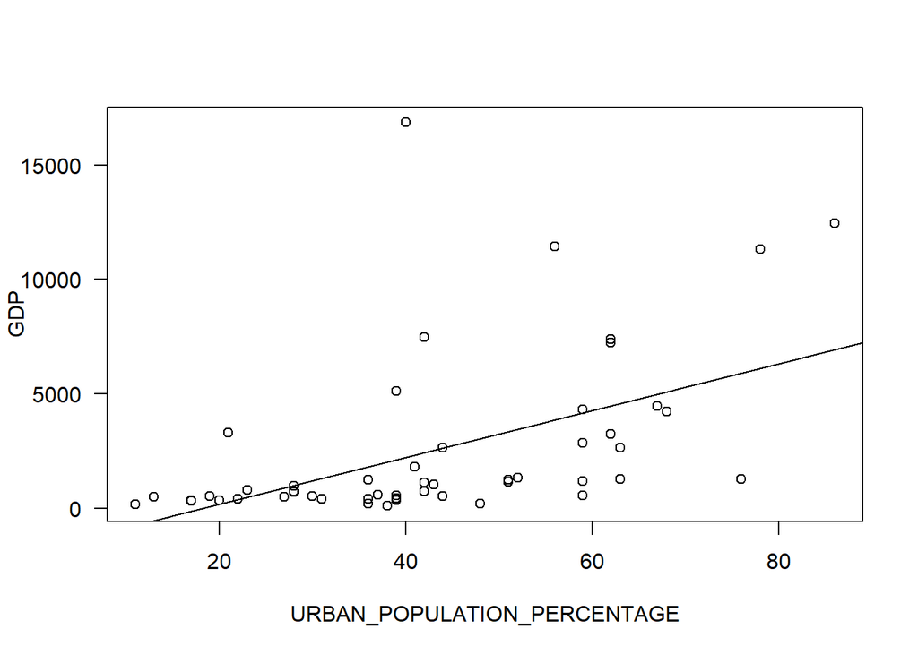

```r
#3. Graphics: Please make sure to display at least one scatter plot, box plot and histogram. Don't be limited to this. Please explore the many other options in R packages such as ggplot2.

#Comparing all other variables against GDPs for countires falling under 3 categories 'africa, 'oecd' and 'other'

#Scatter plots
install.packages("ggplot2",repos = "http://cran.us.r-project.org")
library(ggplot2)
#Compare Urban population against GDP

plot(GDP~URBAN_POPULATION_PERCENTAGE, data = africanCountriesData,las = 1)
abline(lm(GDP~URBAN_POPULATION_PERCENTAGE, data = africanCountriesData))
```

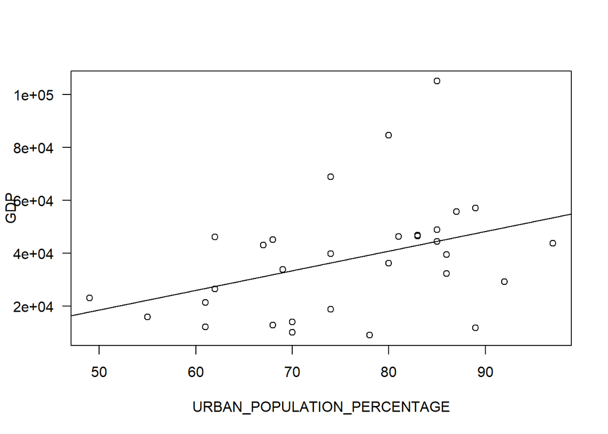

```r
plot(GDP~URBAN_POPULATION_PERCENTAGE, data = oecdCountriesData,las = 1)
abline(lm(GDP~URBAN_POPULATION_PERCENTAGE, data = oecdCountriesData))
```

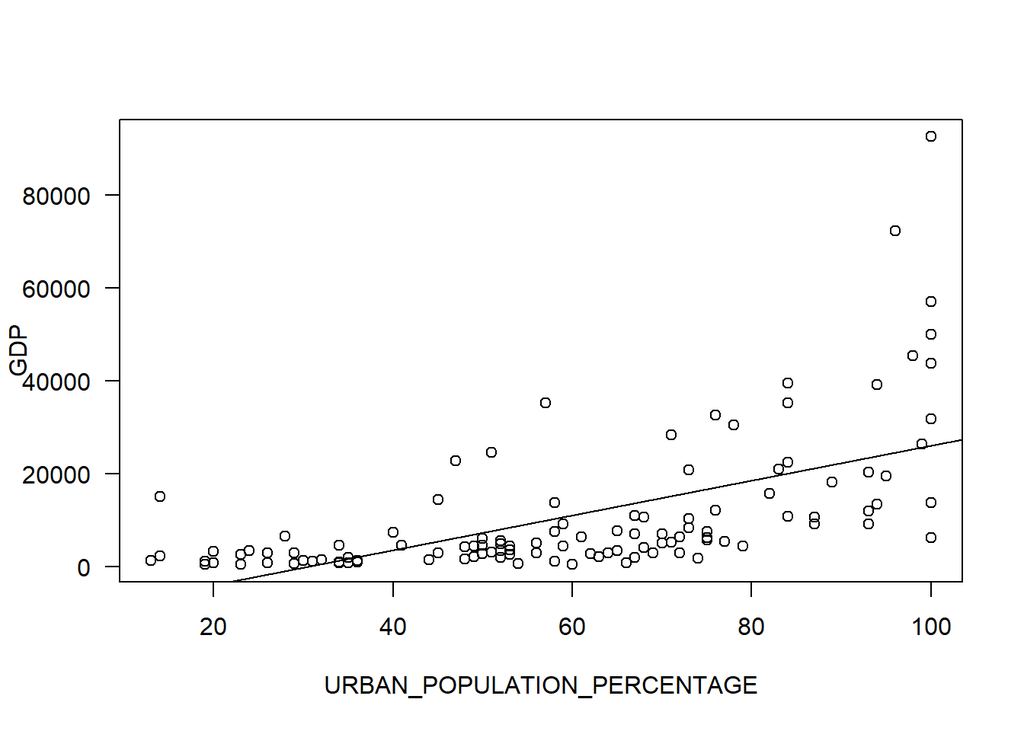

```r
plot(GDP~URBAN_POPULATION_PERCENTAGE, data = otherCountriesData,las = 1)
abline(lm(GDP~URBAN_POPULATION_PERCENTAGE, data = otherCountriesData))
```

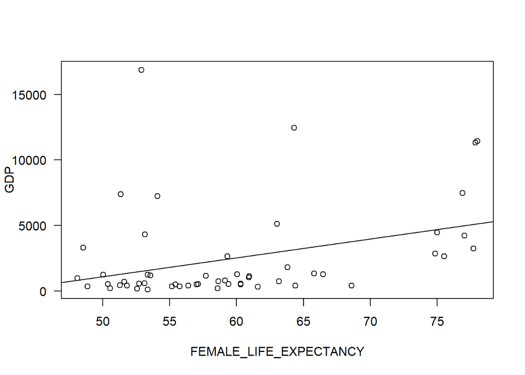

```r
#Compare Female life expectancy against GDP

plot(GDP~FEMALE_LIFE_EXPECTANCY, data = africanCountriesData, las = 1)
abline(lm(GDP~FEMALE_LIFE_EXPECTANCY, data = africanCountriesData))
```

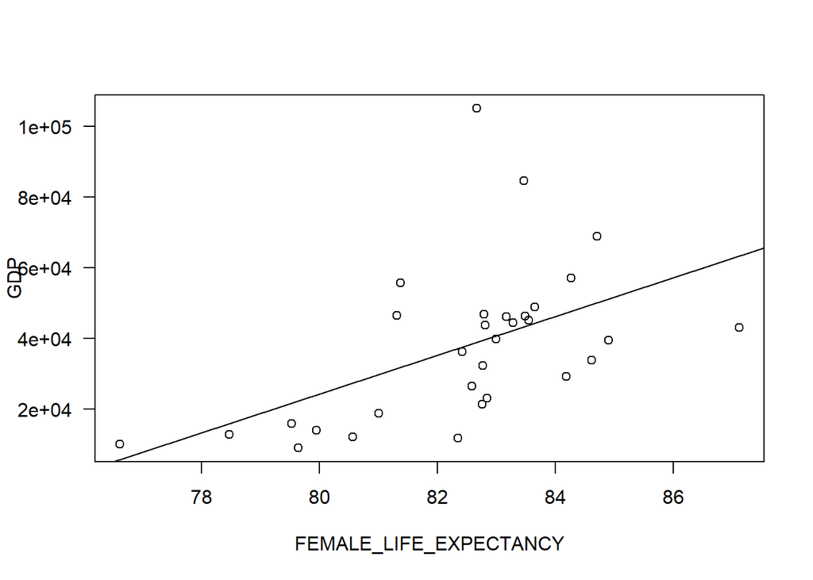

```r
plot(GDP~FEMALE_LIFE_EXPECTANCY, data = oecdCountriesData, las = 1)
abline(lm(GDP~FEMALE_LIFE_EXPECTANCY, data = oecdCountriesData))
```

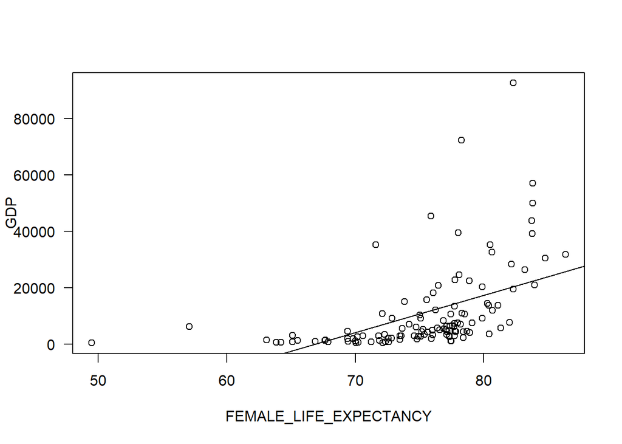

```r
plot(GDP~FEMALE_LIFE_EXPECTANCY, data = otherCountriesData, las = 1)
abline(lm(GDP~FEMALE_LIFE_EXPECTANCY, data = otherCountriesData))
```

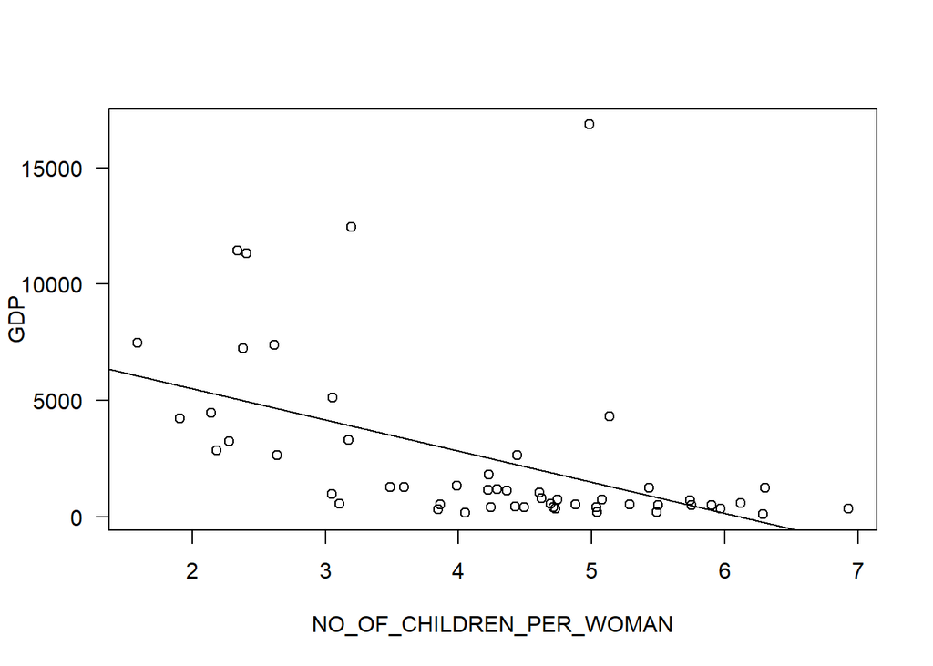

```r
#Compare Number Of Children per woman against GDP

plot(GDP~NO_OF_CHILDREN_PER_WOMAN, data = africanCountriesData, las = 1)
abline(lm(GDP~NO_OF_CHILDREN_PER_WOMAN, data = africanCountriesData))
```

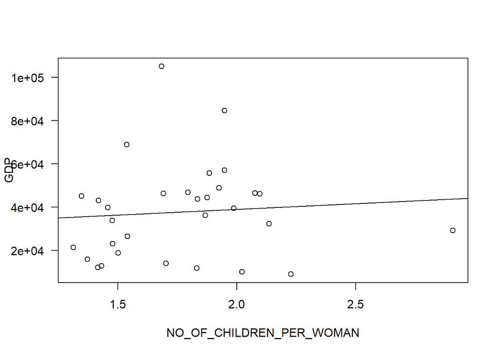

```r
plot(GDP~NO_OF_CHILDREN_PER_WOMAN, data = oecdCountriesData, las = 1)
abline(lm(GDP~NO_OF_CHILDREN_PER_WOMAN, data = oecdCountriesData))
```

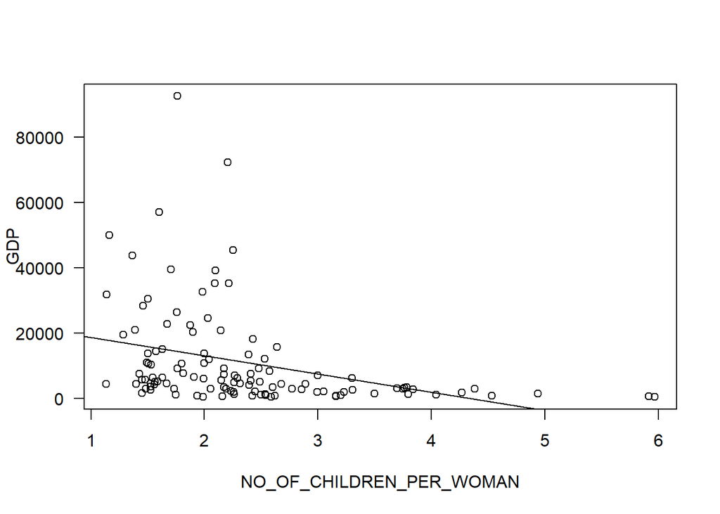

```r
plot(GDP~NO_OF_CHILDREN_PER_WOMAN, data = otherCountriesData, las = 1)
abline(lm(GDP~NO_OF_CHILDREN_PER_WOMAN, data = otherCountriesData))
```

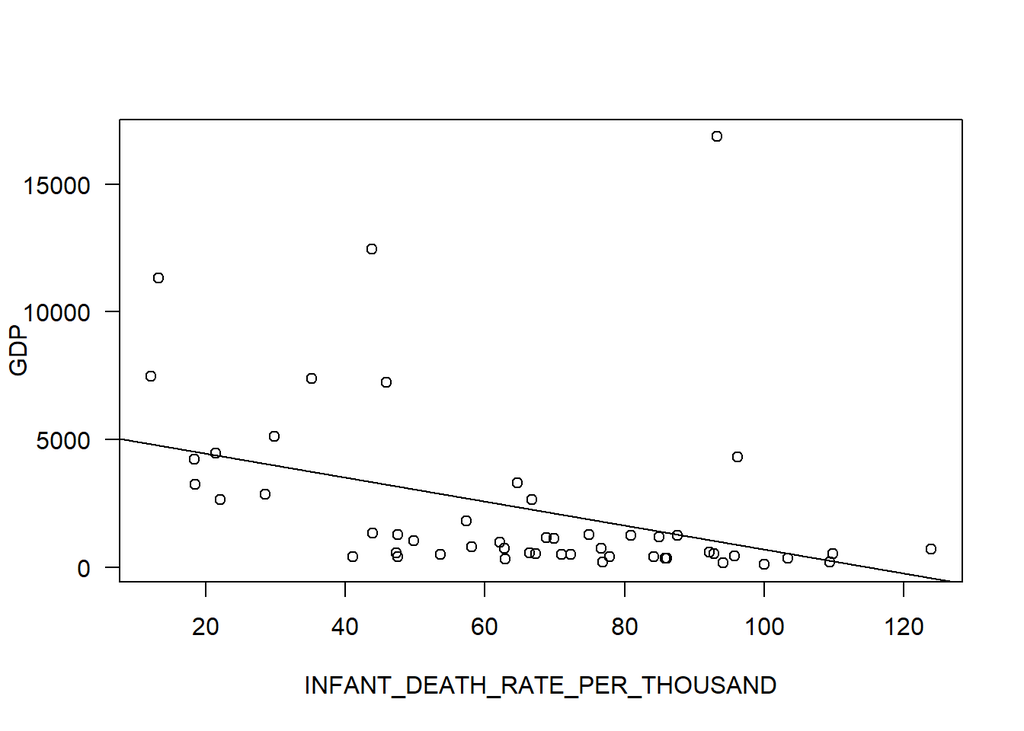

```r
#Compare Infant deaht rate per thousand against GDP

plot(GDP~INFANT_DEATH_RATE_PER_THOUSAND, data = africanCountriesData, las = 1)
abline(lm(GDP~INFANT_DEATH_RATE_PER_THOUSAND, data = africanCountriesData))
```

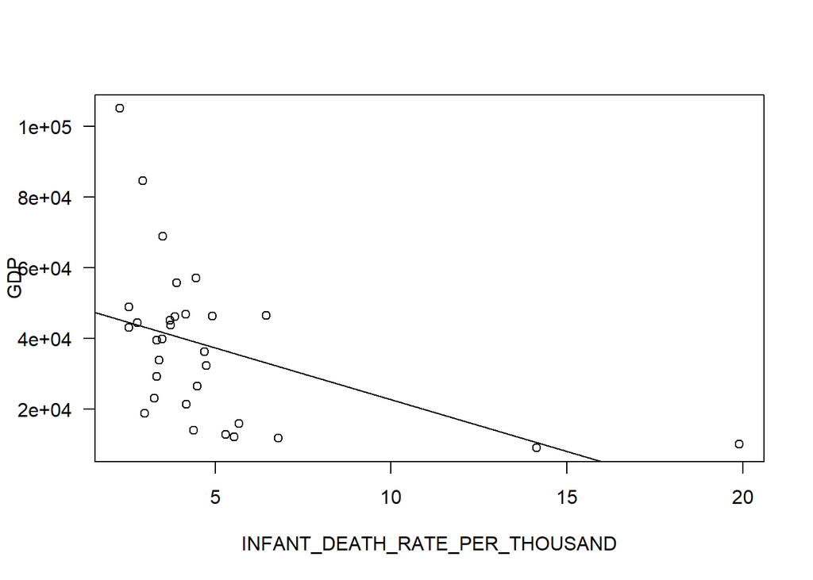

```r
plot(GDP~INFANT_DEATH_RATE_PER_THOUSAND, data = oecdCountriesData, las = 1)
abline(lm(GDP~INFANT_DEATH_RATE_PER_THOUSAND, data = oecdCountriesData))
```

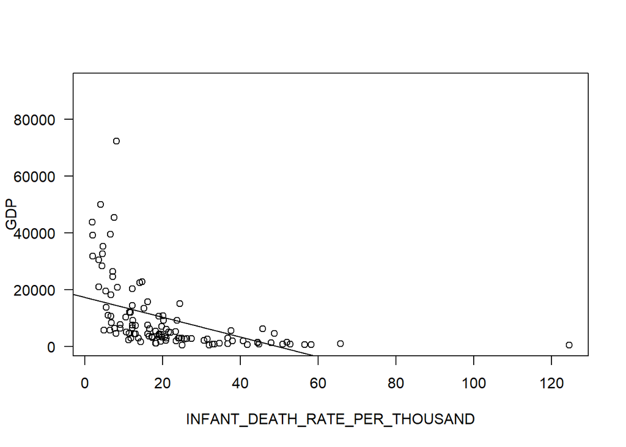

```r
plot(GDP~INFANT_DEATH_RATE_PER_THOUSAND, data = otherCountriesData, las = 1)
abline(lm(GDP~INFANT_DEATH_RATE_PER_THOUSAND, data = otherCountriesData))
```

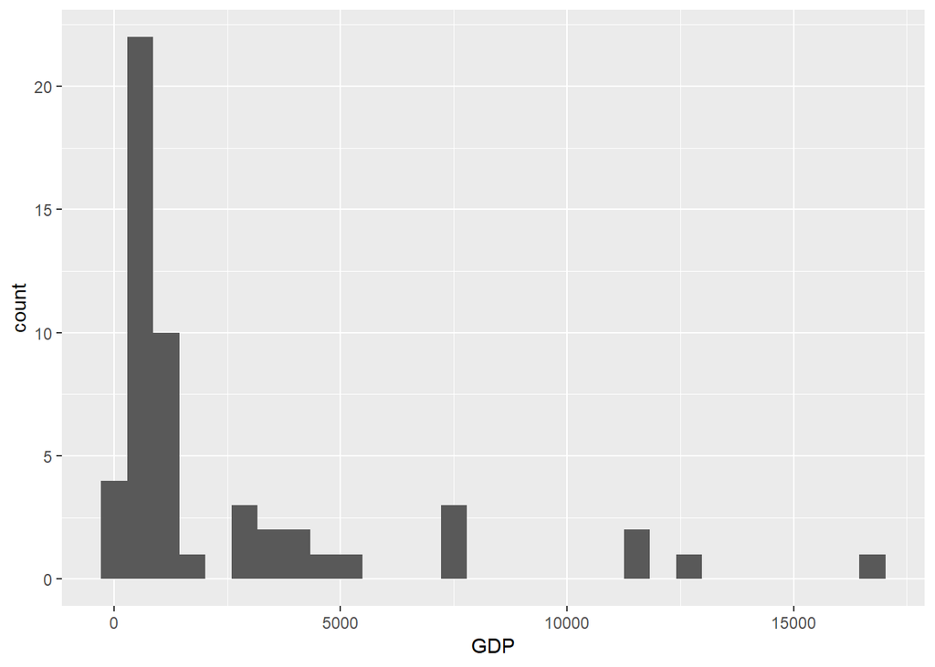

```r
#Histograms For GDP of the countries categorized under 3 groups 'africa', 'oecd' and 'other'

ggplot(africanCountriesData, aes(x = GDP)) +
  geom_histogram()
```

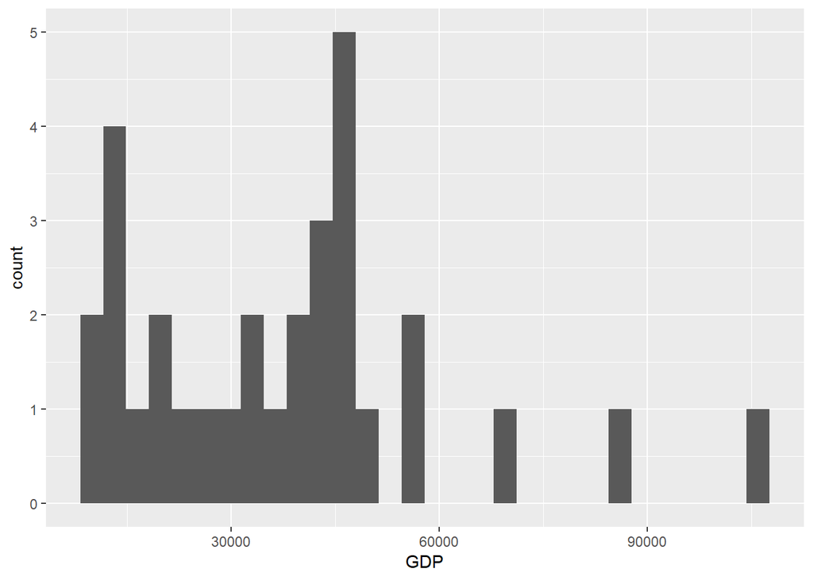

```r
ggplot(oecdCountriesData, aes(x = GDP)) +
  geom_histogram()
```

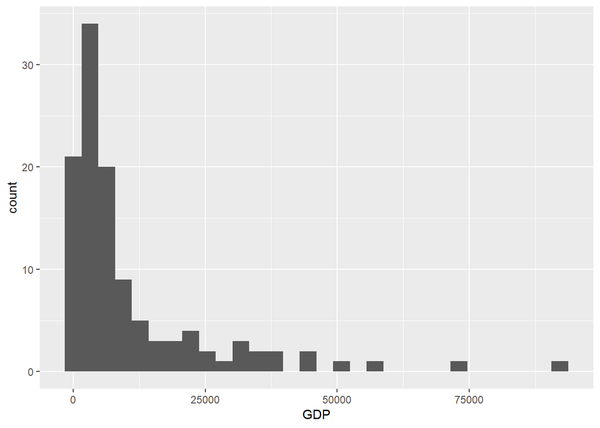

```r
ggplot(otherCountriesData, aes(x = GDP)) +
  geom_histogram()
```

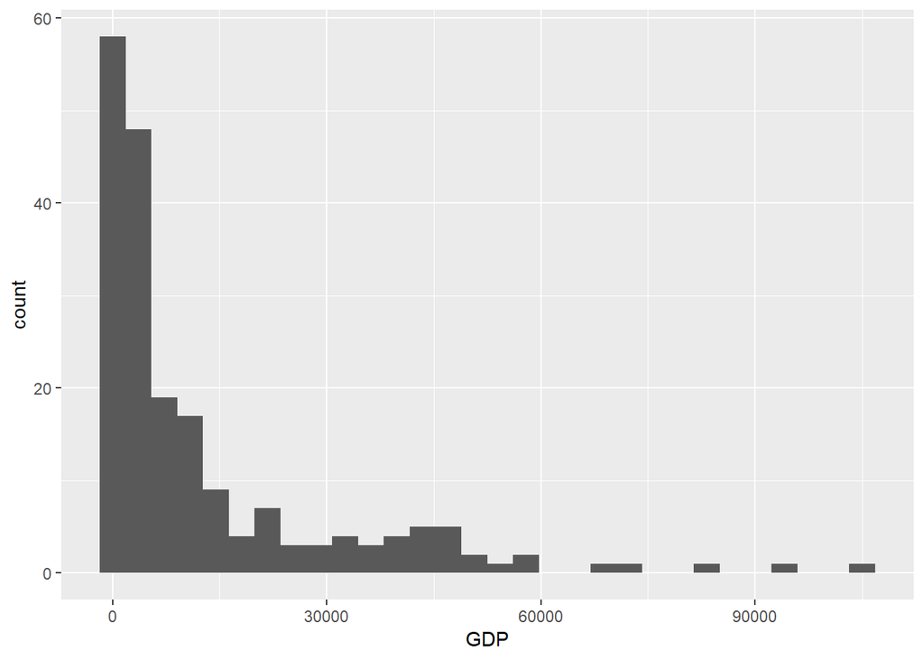

```r
ggplot(UNStatistics,aes(x=GDP)) +
  geom_histogram()
```

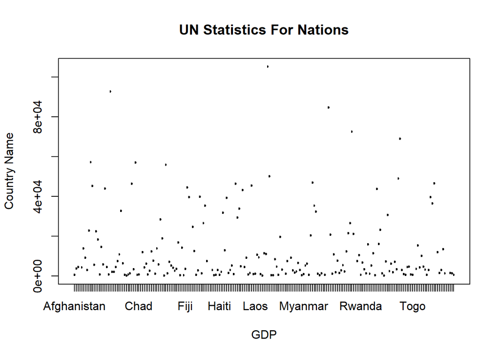

```r
#Box Plots

boxplot(GDP~COUNTRY_NAME,data=UNStatistics, main="UN Statistics For Nations",
   xlab="GDP", ylab="Country Name")
```

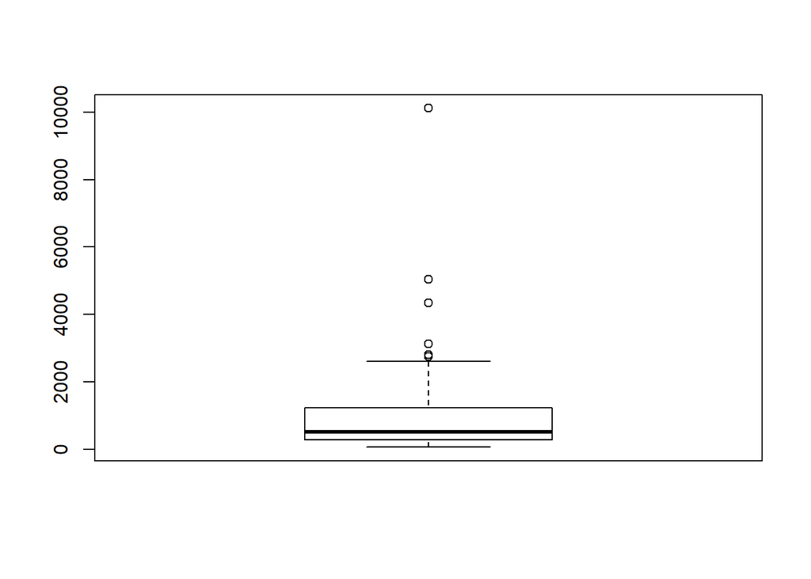

```r
boxplot(africanCountriesData$GDP_RURAL_CONTRIBUTION)
```

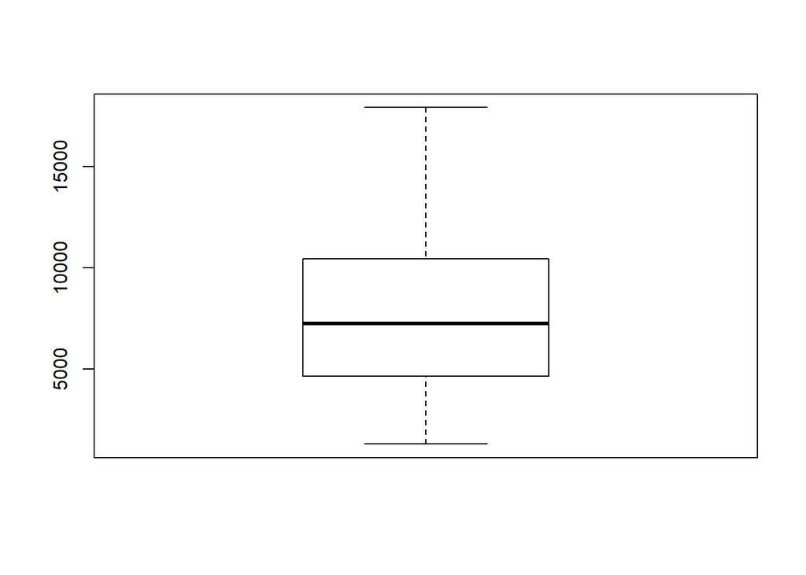

```r
boxplot(oecdCountriesData$GDP_RURAL_CONTRIBUTION)
```

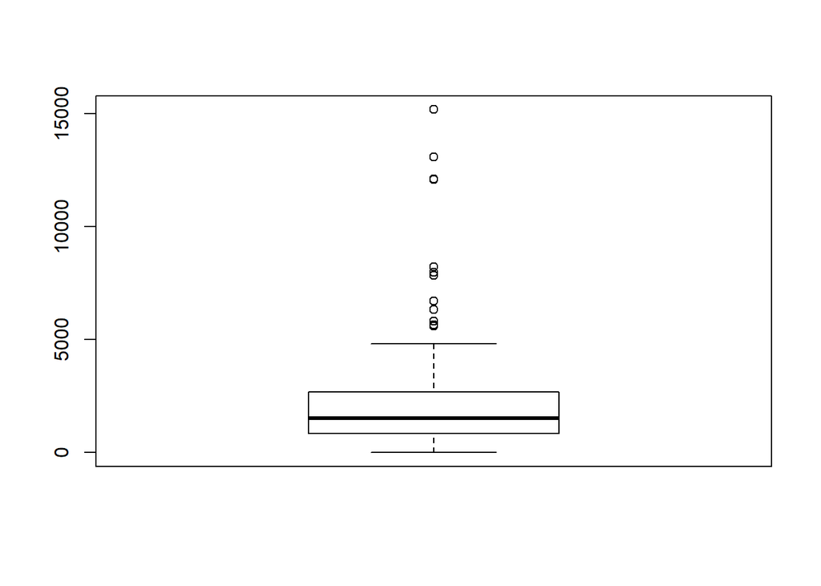

```r
boxplot(otherCountriesData$GDP_RURAL_CONTRIBUTION)
```

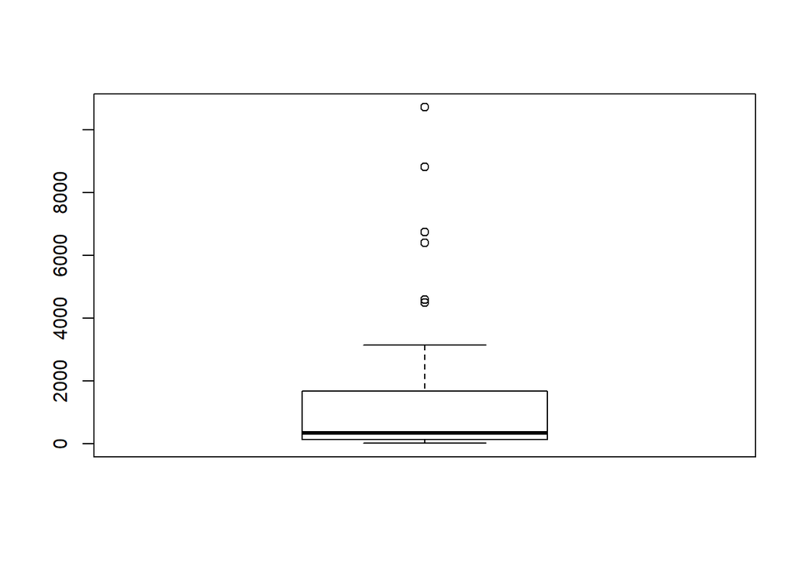

```r
boxplot(africanCountriesData$GDP_URBAN_CONTRIBUTION)
```

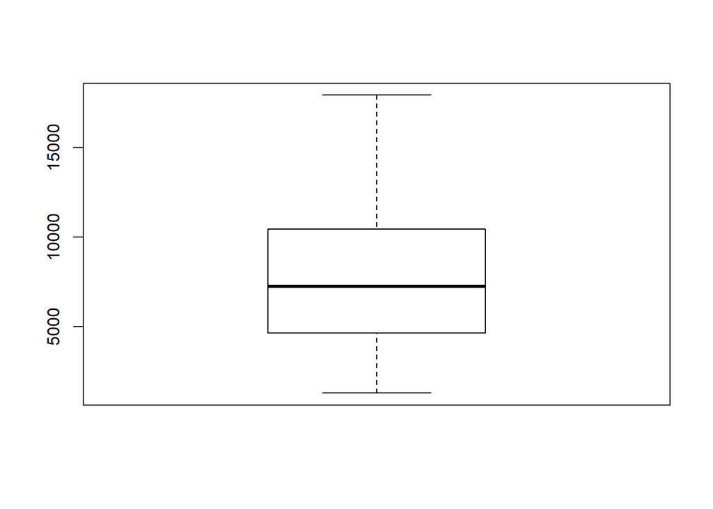

```r
boxplot(oecdCountriesData$GDP_RURAL_CONTRIBUTION)
```

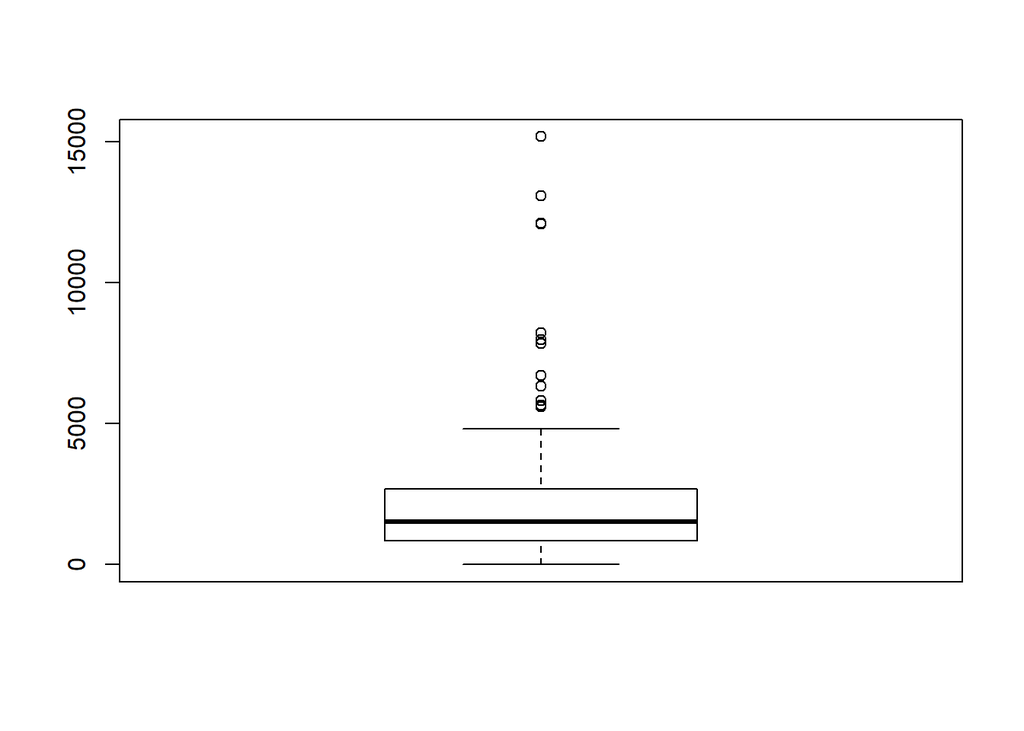

```r
boxplot(otherCountriesData$GDP_RURAL_CONTRIBUTION)
```

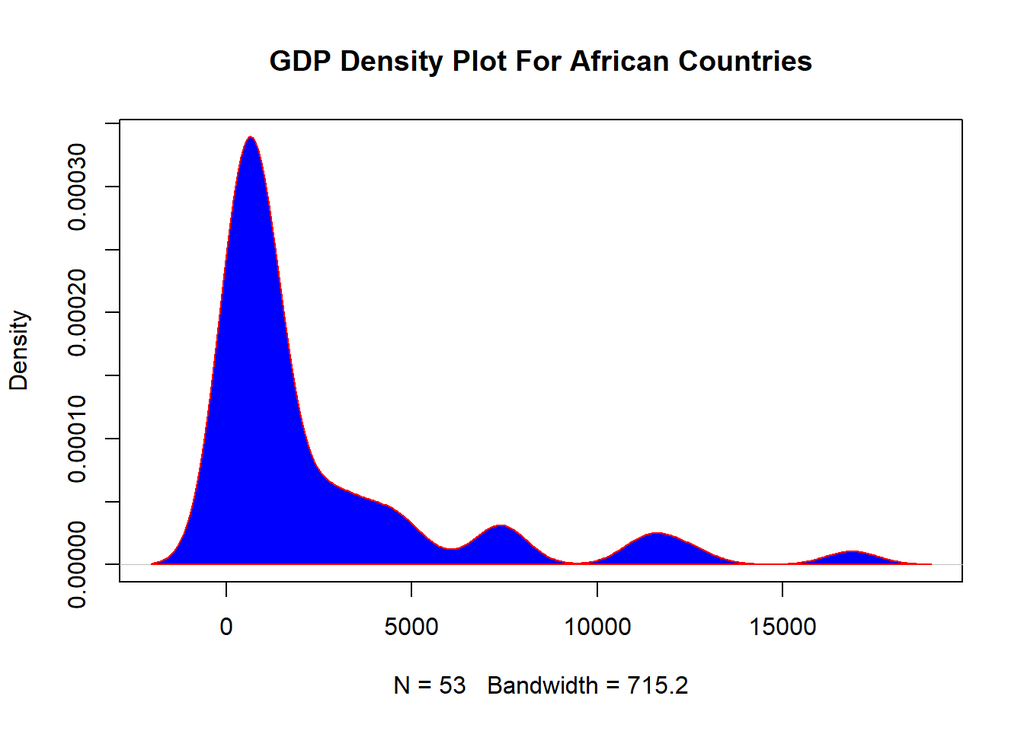

```r
#Density Plots

plot(density(africanCountriesData$GDP),main = "GDP Density Plot For African Countries",col="gold")
polygon(density(africanCountriesData$GDP),main = "GDP Density Plot For African Countries",col="blue",border = "red")
```

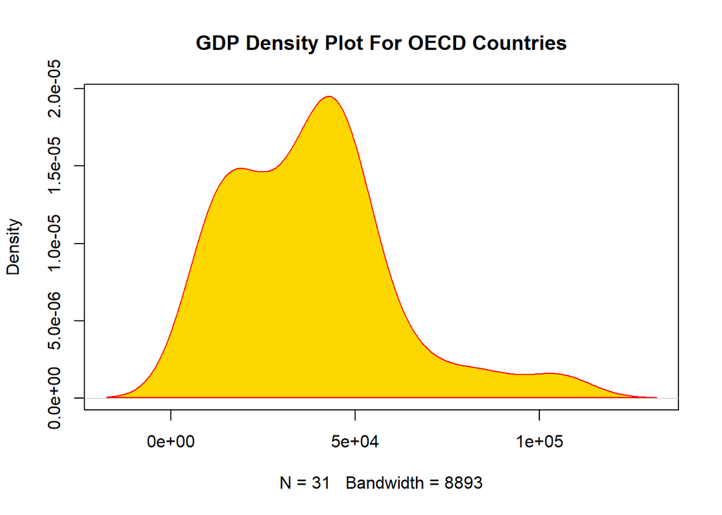

```r
plot(density(oecdCountriesData$GDP),main = "GDP Density Plot For OECD Countries",col="gold")
polygon(density(oecdCountriesData$GDP),main = "GDP Density Plot For OECD Countries",col="gold",border = "red")
```

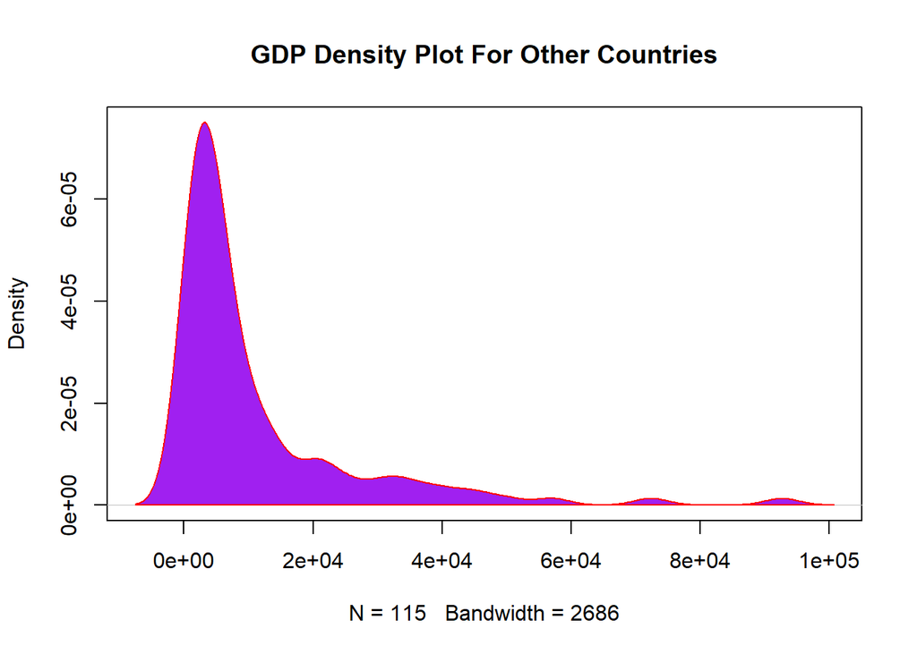

```r
plot(density(otherCountriesData$GDP),main = "GDP Density Plot For Other Countries",col="gold")
polygon(density(otherCountriesData$GDP),main = "GDP Density Plot For Other Countries",col="purple",border = "red")
```

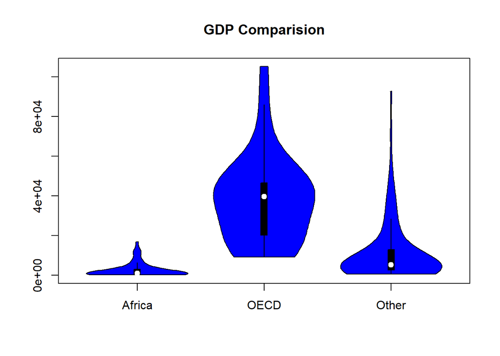

```r
#Violin Plots
install.packages("vioplot",repos = "http://cran.us.r-project.org")
library(vioplot)
GDP_Africa <- africanCountriesData$GDP
GDP_OECD <- oecdCountriesData$GDP
GDP_Other <- otherCountriesData$GDP
vioplot(GDP_Africa, GDP_OECD,GDP_Other, names=c("Africa", "OECD", "Other"),
   col="blue")
title("GDP Comparision")
```

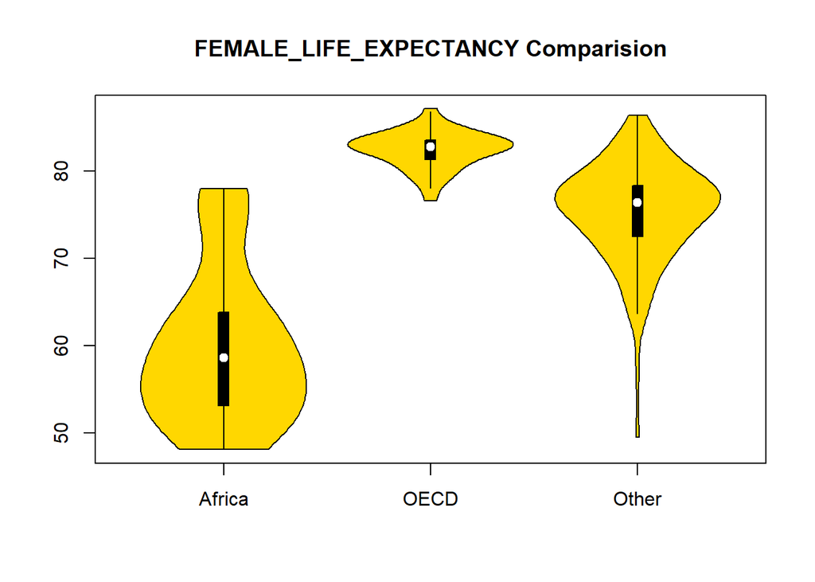

```r
FLP_Africa <- africanCountriesData$FEMALE_LIFE_EXPECTANCY
FLP_OECD <- oecdCountriesData$FEMALE_LIFE_EXPECTANCY
FLP_Other <- otherCountriesData$FEMALE_LIFE_EXPECTANCY
vioplot(FLP_Africa, FLP_OECD,FLP_Other, names=c("Africa", "OECD", "Other"),
   col="gold")
title("FEMALE_LIFE_EXPECTANCY Comparision")
```

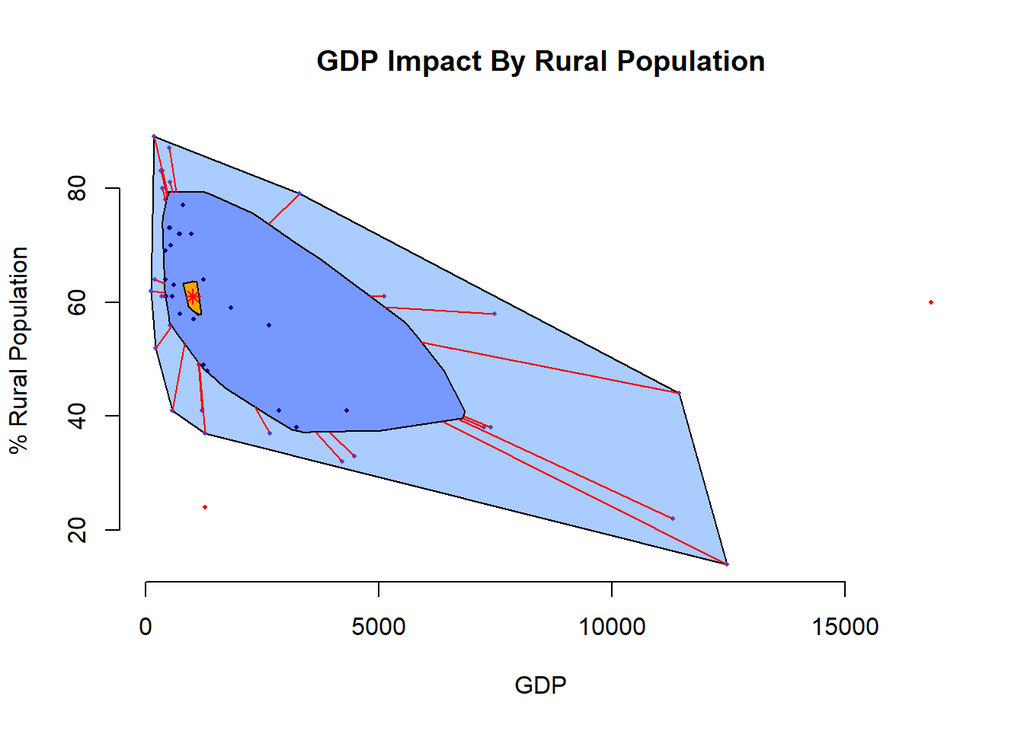

```r
#Bag Plots - 2D extensions of Box Plots

install.packages("aplpack",repos = "http://cran.us.r-project.org")
library(aplpack)
attach(africanCountriesData)
bagplot(GDP,RURAL_POPULATION_PERCENTAGE, xlab="GDP", ylab="% Rural Population",
  main="GDP Impact By Rural Population")
```

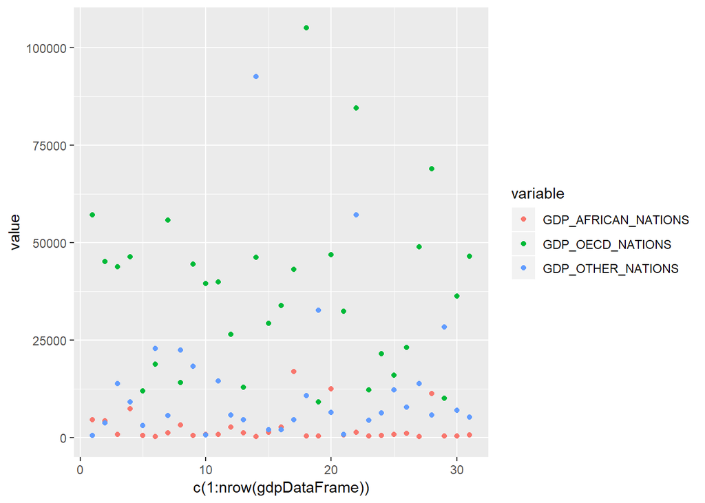

```r
#Comparing GDP's for the countries categorized as one of the 3 Groups 'africa', 'oecd' and 'other'

gdpDataFrame <- data.frame(africanCountriesData$GDP[c(1:nrow(oecdCountriesData))],oecdCountriesData$GDP,otherCountriesData$GDP[c(1:nrow(oecdCountriesData))])
colnames(gdpDataFrame) <- c("GDP_AFRICAN_NATIONS","GDP_OECD_NATIONS","GDP_OTHER_NATIONS")

ggplot(gdpDataFrame, aes(c(1:nrow(gdpDataFrame)), y = value, color = variable)) +
    geom_point(aes(y = GDP_AFRICAN_NATIONS, col = "GDP_AFRICAN_NATIONS")) +
    geom_point(aes(y = GDP_OECD_NATIONS, col = "GDP_OECD_NATIONS")) +     geom_point(aes(y = GDP_OTHER_NATIONS, col = "GDP_OTHER_NATIONS"))
```

```r
#4. Meaningful question for analysis: Please state at the beginning a meaningful question for analysis. Use the first three steps and anything else that would be helpful to answer the question you are posing from the data set you chose. Please write a brief conclusion paragraph in R markdown at the end.
```

Question For Analysis :

Is GDP (Quality OF Living) is dependent on other variables in the observation, such as ‘Urban Population Percentage’ ?

It is clearly observed from above graphs, summary details, that the major contribution of GDP is by urban population. The slope of the linear regression line for the scatter plots are also positive, indicating more the people staying in urban areas, more will be the GDP for the country and the quality of life.

It can also be observed, higher the urban population and GDP, lesser is the probability for infant mortality, lesser will be the children per woman and higher will be the expectancy of females living in the country. We can observe these from the scatter plots and their slopes, which are all negative, indicating, higher the GDP value, lesser will be these values.

Quality of life is dependent on the level of urbanization in the country, which also impacts other variables in the observation.

Also sampling out the observations, with respect to different groups such as ‘africa’, ‘oecd’ and ‘other’, this behavior is observed in all respects. We have also captured different plots for each one of them above.

```r
#5. BONUS - place the original .csv in a github file and have R read from the link. This will be a very useful skill as you progress in your data science education and career.

# This project uses the checked data set in github, this is the url for the dataset, from which this R program reads it - https://raw.githubusercontent.com/samsri01/Repo-For-CSV-File-Storage/master/UN_Statistics.csv
```